# STA207 Hw3 - Eric Kalosa-Kenyon

```r
library("additivityTests")  # interaction plots
library("dae")              # multi-way interaction plots
library("gplots")           # pretty plotting
library("plyr")             # data.frame manipulation
```

# 23.13

## 23.13.a

The full, non-interacting model under consideration for the kidney dataset is $Y_{ijk} = \mu + \alpha_i + \beta_j + \epsilon_{ijk}$ where $\epsilon \sim N(0,\sigma^2)$ iid. The two reduced models under consideration are $Y_{ijk} = \mu + \sum_{l=1}^{a}{\alpha_l*X_{ij,l}} + \epsilon_{ijk}$ and $Y_{ijk} = \mu + \sum_{m=1}^{b}{\beta_j*X_{ij,m}} + \epsilon_{ijk}$, using indicator variables $X_{ij,l} = 1$ if $l=i$, $-1$ if $l=a$, and $0$ otherwise. Similarly, $X_{ij,m} = 1$ if $m=j$, $-1$ if $m=b$, and $0$ otherwise.

## 23.13.b

```r
df = read.csv("kidney.csv")
df$Duration = as.factor(df$Duration)
df$Weight = as.factor(df$Weight)
df$logDays = log(df$Days + 1)
dfu = df[!c((df$Duration == 1) & (df$Weight == 2)),] # Unbalanced
# Use non-interaction additive model and the two factor tests
alp = 0.05
nt = dim(dfu)[1]
a = length(unique(dfu$Weight))
b = length(unique(dfu$Duration))

# Test for A and B factor effects
fit.full = lm(logDays ~ Duration + Weight, dfu)
fit.noWei = lm(logDays ~ Duration, dfu)
fit.noDur = lm(logDays ~ Weight, dfu)
sse_f = sum(fit.full$residuals^2)
sse_nw = sum(fit.noWei$residuals^2)
sse_nd = sum(fit.noDur$residuals^2)
df_f = nt-(a+b-1)
df_nw = nt-(b-1)
df_nd = nt-(a-1)

# Test for significance of factor effects
# qf(1 - alp, df1, df2)
nw.f_emp = ((sse_nw-sse_f)/(df_nw-df_f))/(sse_f/df_f)
nd.f_emp = ((sse_nd-sse_f)/(df_nd-df_f))/(sse_f/df_f)
nw.f_theor = qf(1-alp/2, df_nw-df_f, df_f)
nd.f_theor = qf(1-alp/2, df_nd-df_f, df_f)
# Note that we divide alpha by 2 to Bonferroni correct for multiple comparisons
```

The theoretical F statstic for the weight-only model is $F=4.0011722$ and the emperical F stat is $F^*=1.0181371$. The theoretical F statstic for the duration-only model is $F=3.4153894$ and the emperical F stat $F^*=10.71318$. The decision rule states that we must reject the nill hypothesis when $F^*>F$. In this case, we reject the nill hypothesis that weight does not affect the response variable and we fail to reject the nill hypothesis that duration of stay doesn’t affect the response.

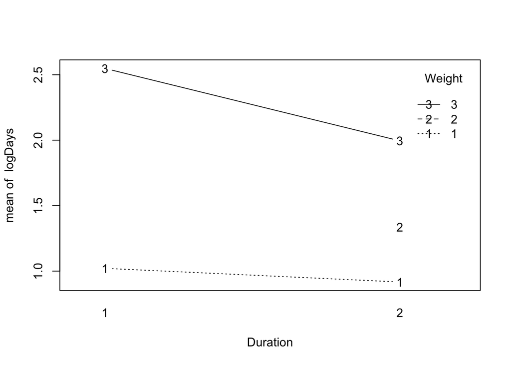

```r
with(dfu, interaction.plot(Duration, Weight, logDays, type="b"))
```

# 23.19

## 23.19.a

The ANOVA model with Tukey interactions, missing $\bar{Y}_{13}$ and $\bar{Y}_{51}$ is
$$Y_{ijk} = \mu +
\sum_{l=1}^{a}{\alpha_l*X_{ij,l}} +
\sum_{m=1}^{b}{\beta_m*X_{ij,l}} +
\sum_{m=1}^{b} \sum_{l=1}^{a}{ D*\alpha_l*\beta_m*X_{ij,l}*X_{ij,m} } +
\epsilon_{ijk}$$
using indicator variables $X_{ij,l} = 1$ if $l=i$, $-1$ if $l=a$, and $0$ otherwise. Similarly, $X_{ij,m} = 1$ if $m=j$, $-1$ if $m=b$, and $0$ otherwise.

## 23.21.b

The reduced model for testing differences between means in the lipid content between diets is
$$Y_{ijk} = \mu + \sum_{l=1}^{a}{\alpha_l*X_{ij,l}} + \epsilon_{ijk}$$
with indicator $X_{ij,l}$ as above. Note that here $a=3$ is the number of diet types and $\alpha_l$ for $l\in\{1,\dots,a\}$ corresponds to the diet effect. $\epsilon_{ijk}$ is distributed as before.

## 23.21.c

```r
# Load data
fat = c(.73, .86, .94, 1.40, 1.62,
        .67, .75, .81, 1.32, 1.41,
        .15, .21, .26, .75, .78)
df1 = data.frame(fat)
age = c()
diet = c()
for (i in 1:length(fat)){
    age = c(age, ((i - 1) %% 5) + 1)
    diet = c(diet, ceiling(i / 5))
}
df1$age = as.factor(age)
df1$diet = as.factor(diet)
dfu1 = df1[!c((df1$age == 1) & (df1$diet == 3)),] # drop 13, 51
dfu1 = dfu1[!c((dfu1$age == 5) & (dfu1$diet == 1)),]

nt = dim(dfu1)[1]
a = length(unique(dfu1$age))
b = length(unique(dfu1$diet))
alp = 0.05
df_f = nt-(a+b-1)
df_r = nt-(b-1)

fit.full1 = with(dfu1, lm(fat ~ age + diet))
fit.diet = with(dfu1, lm(fat ~ diet))
sse_f = sum(fit.full1$residuals^2)
sse_r = sum(fit.diet$residuals^2)
f.emper = ((sse_r-sse_f)/(df_r-df_f))/(sse_f/df_f)
f.theor = qf(1-alp, df_r-df_f, df_f)
```

The critical theoretical F statistic $F^{0.05}=4.3873742$ and the emperical F statistic $F^*=346.2753305$. When $F^*>F^\alpha$ we must reject the null hypothesis. This is the case here, so we reject the nill hypothesis and conclude that diet does indeed affect blood lipid content.

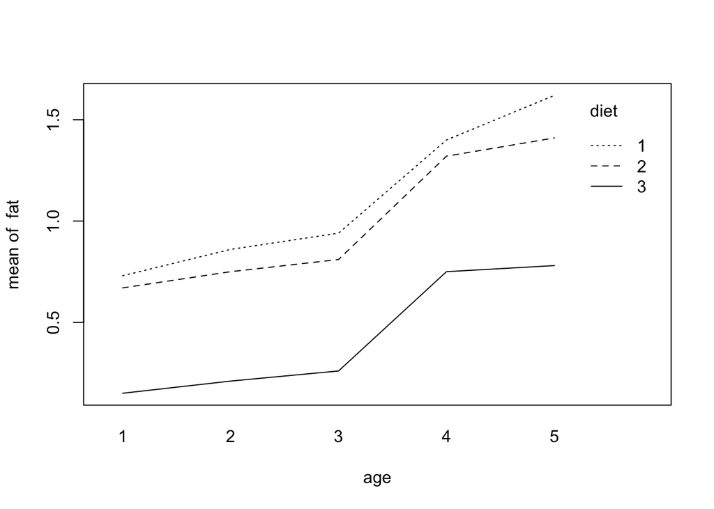

```r
with(fit.full, interaction.plot(age, diet, fat))
```

## 23.19.d

```r
alp = 0.02
d3 = mean(dfu1$fat[dfu1$diet == 3])
d1 = mean(dfu1$fat[dfu1$diet == 1])
C = c(1,-1)
L = d1-d3
ni1 = c()
ni3 = c()
for (i in 1:a){
    ni1.m = 1/sum((dfu1$diet == 1) & (dfu1$age == i))
    if (ni1.m != Inf){
        ni1 = c(ni1, ni1.m)
    }
    ni3.m = 1/sum((dfu1$diet == 3) & (dfu1$age == i))
    if (ni3.m != Inf){
        ni3 = c(ni3, ni3.m)
    }
}
s2 = (sse_f/df_f)/(b^2)*sum(C^2)*(sum(ni1) + sum(ni3))
m = qt(1-alp/2, df_f)
L.intv = sqrt(s2)*m
```

The $1-\alpha=0.98$ confidence interval for the difference in blood lipid content between treatments 1 and 3 is $0.4825\pm0.1012876$.

# 24.12

## 24.12.a

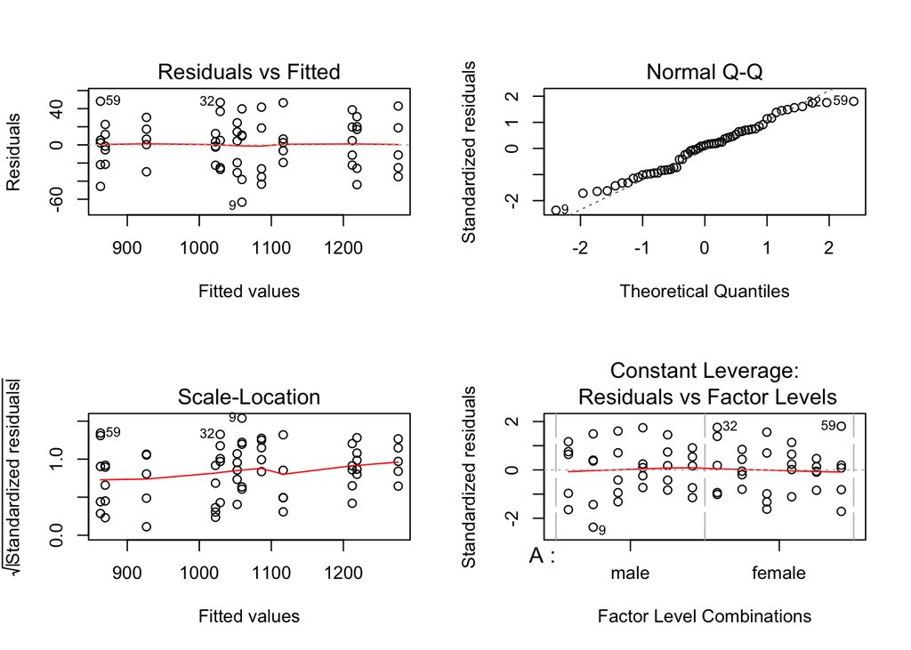

```r
df2 = read.csv("ElectronicsAssembly.csv")
for (col in c("A", "B", "C", "Replication")){
    df2[,col] = as.factor(df2[,col])
}
df2$A = mapvalues(df2$A, from=c(1,2), to=c("male","female"))
df2$C = mapvalues(df2$C, from=c(1,2), to=c("under 18mo","over 18mo"))
fit.elec.aov = with(df2, aov(Time ~ A + B + C))
par(mfrow=c(2,2))
plot(fit.elec.aov)
```

The fitted v residuals plot shows that the residuals are homoskedastic. These observations indicate that the ANOVA model may be appropriate for our analysis.

## 24.12.b

```r
res = fit.elec.aov$residuals
fvs = fit.elec.aov$fitted.values
coef.cor = cov(res, fvs) / sqrt(var(res)*var(fvs))
```

The QQ plot shows that the residuals might have slightly smaller spread than a theoretical normal distribution, but they are otherwise sufficiently normal throughout the majority of observations. The coefficient of correlation between the fitted values and residuals is $4.1091621\times 10^{-16}$, which is sufficiently close to $0$ for us to conclude that the fitted values and the residuals have no linear correlation.

# 24.13

## 24.13.a

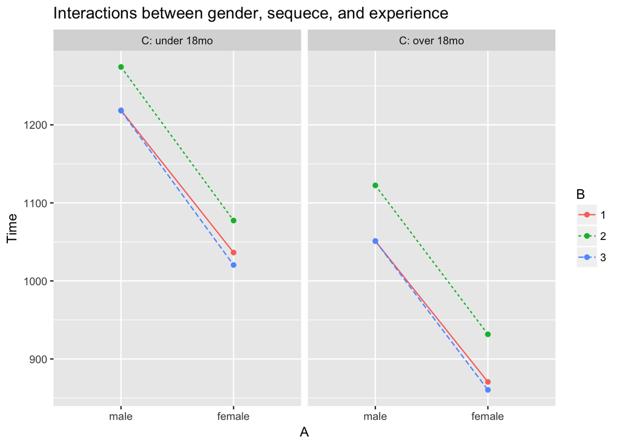

```r
interaction.ABC.plot(
    response = Time,
    x.factor = A,
    groups.factor = B,
    trace.factor = C,
    data = df2,
    title = "Interactions between gender, sequece, and experience"
    )
```

## 24.13.b

```r
fit.full = with(df2, aov(Time ~ A*B*C))
anova(fit.full) # note that the data is balanced across all factors
```

```
## Analysis of Variance Table
##
## Response: Time
##           Df Sum Sq Mean Sq  F value    Pr(>F)
## A          1 540361  540361 629.7603 < 2.2e-16 ***
## B          2  49320   24660  28.7396  6.22e-09 ***
## C          1 382402  382402 445.6679 < 2.2e-16 ***
## A:B        2    543     271   0.3161    0.7305
## A:C        1     91      91   0.1064    0.7457
## B:C        2    911     456   0.5310    0.5914
## A:B:C      2     19      10   0.0111    0.9890
## Residuals 48  41186     858
## ---
## Signif. codes:  0 '***' 0.001 '**' 0.01 '*' 0.05 '.' 0.1 ' ' 1
```

## 24.13.c

```r
# parameterize analysis
alp = 0.05
a = length(unique(df2$A))
b = length(unique(df2$B))
c = length(unique(df2$C))
n = length(unique(df2$Replication))

# determine degrees of freedom for following tests
df.abc = (a-1)*(b-1)*(c-1)
df.e = (n-1)*a*b*c

# calculate sum of squares of 3-way interactions and errors
co = fit.full$coefficients
# use that sum_i(abc_ijk) = 0 for all j, k to calculate missing coefs
intns3 = c(co[11], -co[11], -co[11], co[11], co[12], -co[12], -co[12], co[12],
           -(co[11]+co[12]), -(co[11]+co[12]), co[11]+co[12], co[11]+co[12]
        )
ss.abc = n*sum(intns3^2)
ss.e = sum(fit.full$residuals^2)

# calculate mse and perform the F test
ms.abc = ss.abc/df.abc
ms.e = ss.e/df.e
f.emp = ms.abc/ms.e
f.theor = qf(1-alp, df.abc, df.e)
p.abc = 1-pf(f.emp, df.abc, df.e)
```

## 24.13.d

```r
df.ab = (a-1)*(b-1)
df.ac = (a-1)*(c-1)
df.bc = (b-1)*(c-1)

intnsAB = c(-(co[6]+co[7]), co[6], co[7], co[6]+co[7], -co[6], -co[7])
intnsAC = c(co[8], -co[8], -co[8], co[8])
intnsBC = c(-(co[9]+co[10]), co[9], co[10], co[9]+co[10], -co[9], -co[10])

ss.ab = n*c*sum(intnsAB^2)
ss.ac = n*b*sum(intnsAC^2)
ss.bc = n*a*sum(intnsBC^2)

# calculate mse and perform the F test
ms.ab = ss.ab/df.ab
ms.ac = ss.ac/df.ac
ms.bc = ss.bc/df.bc
f.emp.ab = ms.ab/ms.e
f.emp.ac = ms.ac/ms.e
f.emp.bc = ms.bc/ms.e
f.theor.ab = qf(1-alp/3, df.ab, df.e) # note: divide alpha by 3 for Bonferroni
f.theor.ac = qf(1-alp/3, df.ac, df.e)
f.theor.bc = qf(1-alp/3, df.bc, df.e)
p.ab = 1-pf(f.emp.ab, df.ab, df.e)
p.ac = 1-pf(f.emp.ac, df.ac, df.e)
p.bc = 1-pf(f.emp.bc, df.bc, df.e)
```

## 24.13.e

```r
df.a = a-1
df.b = b-1
df.c = c-1

eff.A = c(co[2], -co[2])
eff.B = c(co[3], co[4], -(co[3]+co[4]))
eff.C = c(co[5], -co[5])

ss.a = n*b*c*sum(eff.A^2)
ss.b = n*a*c*sum(eff.B^2)
ss.c = n*a*b*sum(eff.C^2)

# calculate mse and perform the F test
ms.a = ss.a/df.a
ms.b = ss.b/df.b
ms.c = ss.c/df.c
f.emp.a = ms.a/ms.e
f.emp.b = ms.b/ms.e
f.emp.c = ms.c/ms.e
f.theor.a = qf(1-alp/3, df.a, df.e) # note: divide alpha by 3 for Bonferroni
f.theor.b = qf(1-alp/3, df.b, df.e)
f.theor.c = qf(1-alp/3, df.c, df.e)
p.a = 1-pf(f.emp.a, df.a, df.e)
p.b = 1-pf(f.emp.b, df.b, df.e)
p.c = 1-pf(f.emp.c, df.c, df.e)
```

## 24.13.f

```r
alp.kimball = 1 - alp - 3*alp/3 - 3*alp/3
```

Using the Kimball inequality, we can make these conclusions with confidence $\alpha_{Kimball}=0.85$.

## 24.13.g

# 24.14

## 24.14.a

```r
alp = 0.10
ncomp = 5
d1 = with(df2, mean(Time[A == "female"]) - mean(Time[A == "male"]))
d2 = with(df2, mean(Time[B == 1]) - mean(Time[B == 2]))
d3 = with(df2, mean(Time[B == 1]) - mean(Time[B == 3]))
d4 = with(df2, mean(Time[B == 2]) - mean(Time[B == 3]))
d5 = with(df2, mean(Time[C == 1]) - mean(Time[C == 2]))
s1 = sqrt(2*ms.e/(n*b*c))
s2 = sqrt(2*ms.e/(n*a*c))
s3 = sqrt(2*ms.e/(n*a*c))
s4 = sqrt(2*ms.e/(n*a*c))
s5 = sqrt(2*ms.e/(n*b*a))
m = qt(1-alp/(ncomp*2), (n-1)*a*b*c)
```

The five confidence intervals for the contrasts follow:

[output not shown]

All the contrasts above, with the exception of $\hat{D}_3$, do not contain zero. That is, we conclude with $\alpha=0.1$ that men are different from women, part ordering $2$ has a different response from the others, part orderings $1$ and $3$ have the same effect on the response, and the different levels of experience have different effects on the response.

## 24.14.b

```r
alp = 0.05
u231 = with(df2, mean(Time[A == "female" & B == 3 & C == 1]))
n231 = with(df2, sum(A == "female" & B == 3 & C == 1))
su = sqrt(ms.e/n231)
m = qt(1-alp/2, (n-1)*a*b*c)
```

$\hat{\mu}_{231}=1020.4\pm26.33919$ seconds.